# CNN Cancer Detection Kaggle Mini-Project

## 1. Explorary Data Analysis

```python
import pandas as pd
import numpy as np
import seaborn as sns

import matplotlib.pyplot as plt
from tifffile import imread

import keras,os
from keras.models import Sequential
from keras.layers import Dense, Conv2D, MaxPool2D , Flatten, BatchNormalization, Activation, Dropout
from keras.preprocessing.image import ImageDataGenerator
from keras.optimizers import Adam
```

```python
label_train = pd.read_csv('\_labels.csv')
image_train = label_train
image_train['label'] = image_train['label'].astype(str)
image_train['id'] = label_train['id'] + '.tif'

print(image_train.head(), '\n')
print(label_train.head(), '\n')
print(label_train.info())
```

```
                                             id label
0  f38a6374c348f90b587e046aac6079959adf3835.tif     0
1  c18f2d887b7ae4f6742ee445113fa1aef383ed77.tif     1
2  755db6279dae599ebb4d39a9123cce439965282d.tif     0
3  bc3f0c64fb968ff4a8bd33af6971ecae77c75e08.tif     0
4  068aba587a4950175d04c680d38943fd488d6a9d.tif     0

                                             id label
0  f38a6374c348f90b587e046aac6079959adf3835.tif     0
1  c18f2d887b7ae4f6742ee445113fa1aef383ed77.tif     1
2  755db6279dae599ebb4d39a9123cce439965282d.tif     0
3  bc3f0c64fb968ff4a8bd33af6971ecae77c75e08.tif     0
4  068aba587a4950175d04c680d38943fd488d6a9d.tif     0

<class 'pandas.core.frame.DataFrame'>
RangeIndex: 220025 entries, 0 to 220024
Data columns (total 2 columns):
 #   Column  Non-Null Count   Dtype
---  ------  --------------   -----
 0   id      220025 non-null  object
 1   label   220025 non-null  object
dtypes: object(2)
memory usage: 3.4+ MB
None
```

```
1.468945319074924
```

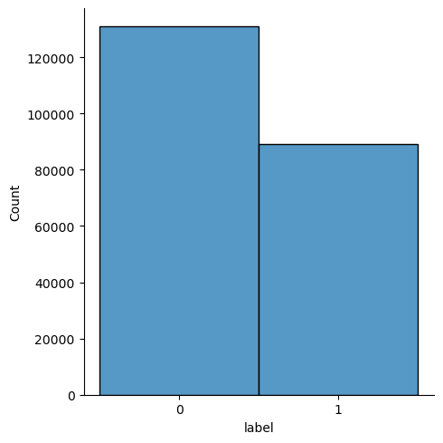

```python
sns.displot(data=label_train, x='label')
label_count = label_train['label'].value_counts()
print(label_count[0] / label_count[1])
```

### The above shows that in the train data, there are 220025 entries without any null data.

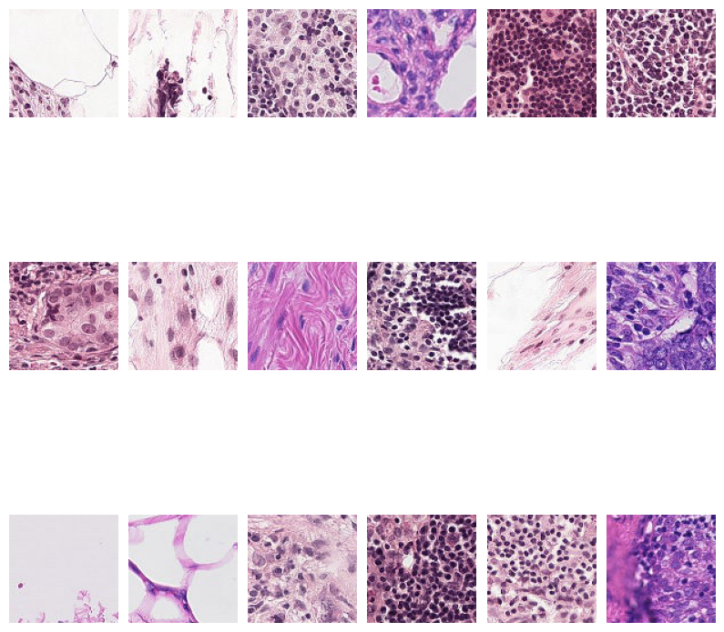

```python
rows, cols = 3, 6

fig, axes = plt.subplots(rows, cols, figsize=(10, 10))

for i in range(3 * 6):
    image = imread('/train/' + image_train['id'][i])

    row, col = i // cols, i % cols

    axes[row, col].imshow(image)
    axes[row, col].axis('off')

plt.subplots_adjust(wspace = 0.1, hspace = 0.3)

plt.show()
```

## 2. Modeling

### (1) First model

### Conv2D -> Conv2D -> MaxPool2D -> Conv2D -> Conv2D -> MaxPool2D -> Flatten -> Dense -> Dense -> output

### The activation function of hidden layer except for the output layer is "relu", and that of output layer is "sigmoid."

### Any stride is not applied, because the images seem homogeneous.

```python
model = Sequential()

model.add(Conv2D(filters=16, kernel_size=(3,3), activation='relu'))
model.add(Conv2D(filters=16, kernel_size=(3,3), activation='relu'))
model.add(MaxPool2D(pool_size=(2,2)))

model.add(Conv2D(filters=32, kernel_size=(3,3), activation='relu'))
model.add(Conv2D(filters=32, kernel_size=(3,3), activation='relu'))
model.add(MaxPool2D(pool_size=(2,2)))

model.add(Flatten())
model.add(Dense(units=256, activation='relu'))
model.add(Dense(units=1, activation='sigmoid'))

batch_size = 256

model.build(input_shape=(batch_size, 64, 64, 3))

model.summary()
```

```
Model: "sequential"
_________________________________________________________________
 Layer (type)                Output Shape              Param #
=================================================================
 conv2d (Conv2D)             (256, 62, 62, 16)         448

 conv2d_1 (Conv2D)           (256, 60, 60, 16)         2320

 max_pooling2d (MaxPooling2D  (256, 30, 30, 16)        0
 )

 conv2d_2 (Conv2D)           (256, 28, 28, 32)         4640

 conv2d_3 (Conv2D)           (256, 26, 26, 32)         9248

 max_pooling2d_1 (MaxPooling  (256, 13, 13, 32)        0
 2D)

 flatten (Flatten)           (256, 5408)               0

 dense (Dense)               (256, 256)                1384704

 dense_1 (Dense)             (256, 1)                  257

=================================================================
Total params: 1,401,617
Trainable params: 1,401,617
Non-trainable params: 0
_________________________________________________________________
```

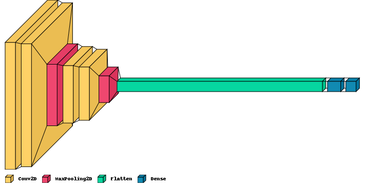

```python
os.system('pip install visualkeras')
import visualkeras
visualkeras.layered_view(model, legend=True)
```

### Splitting training data in training / validation

```python
generator = ImageDataGenerator(rescale=1./255, validation_split=0.25)

data_train = generator.flow_from_dataframe(
    dataframe = image_train,
    x_col='id', # filenames
    y_col='label', # labels
    directory='/train/',
    subset='training',
    class_mode='binary',
    batch_size=batch_size,
    target_size=(64, 64))

data_validate=generator.flow_from_dataframe(
    dataframe=image_train,
    x_col='id', # filenames
    y_col='label', # labels
    directory='/train/',
    subset="validation",
    class_mode='binary',
    batch_size=batch_size,
    target_size=(64, 64))
```

```
Found 165019 validated image filenames belonging to 2 classes.
Found 55006 validated image filenames belonging to 2 classes.
```

### Compiling / Training

#### Learning rate is set to 0.0001.

```python
opt = Adam(learning_rate=0.0001)

model.compile(optimizer=opt, loss='binary_crossentropy', metrics=['accuracy'])
```

```python
hist = model.fit(data_train, validation_data=data_validate, epochs=10)
```

### Evaluation of the first model

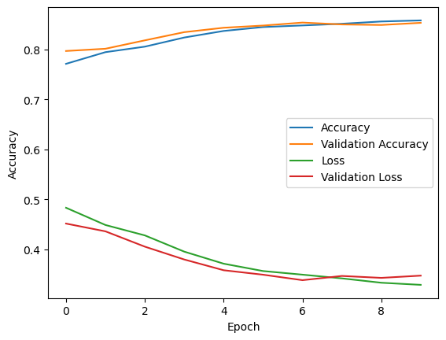

```python
plt.plot(hist.history["accuracy"])
plt.plot(hist.history['val_accuracy'])
plt.plot(hist.history['loss'])
plt.plot(hist.history['val_loss'])

plt.ylabel("Accuracy")
plt.xlabel("Epoch")
plt.legend(["Accuracy","Validation Accuracy","Loss","Validation Loss"])

plt.show()
```

### Accuracy curves of "Accuracy" and "Validation Accuracy" are gradually larger, which means no overfitting. As both accuracy is over 0.8, this model would seem to be well fitted.

### (2) 2nd model -- Batch normalization

### At the 2nd model, batch normalization is tried: Based on the first model, 4 batch normalization layers are inserted between convolution layers / convolution layer and max pooling layer.

```python
model_bn = Sequential()

model_bn.add(Conv2D(filters=16, kernel_size=(3,3)))
model_bn.add(BatchNormalization())
model_bn.add(Activation('relu'))
model_bn.add(Conv2D(filters=16, kernel_size=(3,3)))
model_bn.add(BatchNormalization())
model_bn.add(Activation('relu'))
model_bn.add(MaxPool2D(pool_size=(2,2)))

model_bn.add(Conv2D(filters=32, kernel_size=(3,3)))
model_bn.add(BatchNormalization())
model_bn.add(Activation('relu'))
model_bn.add(Conv2D(filters=32, kernel_size=(3,3)))
model_bn.add(BatchNormalization())
model_bn.add(Activation('relu'))
model_bn.add(MaxPool2D(pool_size=(2,2)))

model_bn.add(Flatten())
model_bn.add(Dense(units=256, activation='relu'))
model_bn.add(Dense(units=1, activation='sigmoid'))

model_bn.build(input_shape=(batch_size, 64, 64, 3))

model_bn.summary()
```

```
Model: "sequential_1"
_________________________________________________________________
 Layer (type)                Output Shape              Param #
=================================================================
 conv2d_4 (Conv2D)           (256, 62, 62, 16)         448

 batch_normalization (BatchN  (256, 62, 62, 16)        64
 ormalization)

 activation (Activation)     (256, 62, 62, 16)         0

 conv2d_5 (Conv2D)           (256, 60, 60, 16)         2320

 batch_normalization_1 (Batc  (256, 60, 60, 16)        64
 hNormalization)

 activation_1 (Activation)   (256, 60, 60, 16)         0

 max_pooling2d_2 (MaxPooling  (256, 30, 30, 16)        0
 2D)

 conv2d_6 (Conv2D)           (256, 28, 28, 32)         4640

 batch_normalization_2 (Batc  (256, 28, 28, 32)        128
 hNormalization)

 activation_2 (Activation)   (256, 28, 28, 32)         0

 conv2d_7 (Conv2D)           (256, 26, 26, 32)         9248

 batch_normalization_3 (Batc  (256, 26, 26, 32)        128
 hNormalization)

 activation_3 (Activation)   (256, 26, 26, 32)         0

 max_pooling2d_3 (MaxPooling  (256, 13, 13, 32)        0
 2D)

 flatten_1 (Flatten)         (256, 5408)               0

 dense_2 (Dense)             (256, 256)                1384704

 dense_3 (Dense)             (256, 1)                  257

=================================================================
Total params: 1,402,001
Trainable params: 1,401,809
Non-trainable params: 192
_________________________________________________________________
```

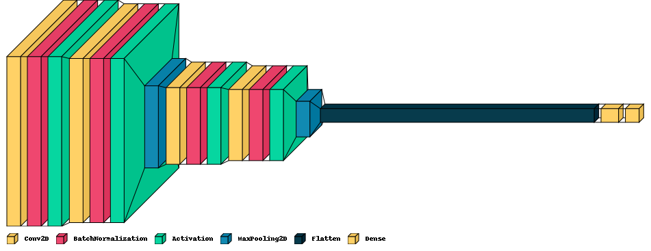

```python
visualkeras.layered_view(model_bn, legend=True)
```

### Compiling / Training

```python
opt_bn = Adam(learning_rate=0.0001)

model_bn.compile(optimizer=opt_bn, loss='binary_crossentropy', metrics=['accuracy'])
```

```python
hist_bn = model_bn.fit(data_train, validation_data=data_validate, epochs=10)
```

### Evaluation of the 2nd model

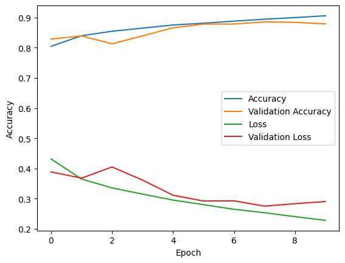

```python
plt.plot(hist_bn.history["accuracy"])
plt.plot(hist_bn.history['val_accuracy'])
plt.plot(hist_bn.history['loss'])
plt.plot(hist_bn.history['val_loss'])

plt.ylabel("Accuracy")
plt.xlabel("Epoch")
plt.legend(["Accuracy","Validation Accuracy","Loss","Validation Loss"])

plt.show()
```

### Not any overfitting would be found according to 2 curves. (There might be some slight inconsistency of validation accuracy.) As final accuracy is over 0.9, the second model is better fitted than the first model.

### (3) 3rd Model -- VGGNet

### VGGNet model is tried.

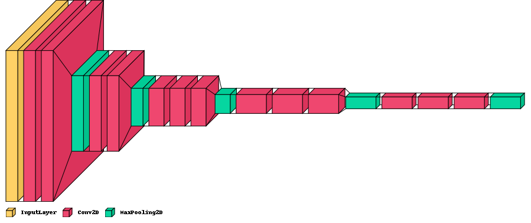

```python
import tensorflow as tf

base_model = tf.keras.applications.VGG16(
    input_shape = (64,64,3),
    include_top=False,
    weights = 'imagenet'
    )
visualkeras.layered_view(base_model, legend = True)
```

```python
model_VGG = Sequential()
model_VGG.add(base_model)
model_VGG.add(Flatten())
model_VGG.add(BatchNormalization())
model_VGG.add(Dense(16, activation = 'relu'))
model_VGG.add(Dropout(0.5))
model_VGG.add(Dense(8, activation = 'relu'))
model_VGG.add(Dropout(0.5))
model_VGG.add(BatchNormalization())
model_VGG.add(Dense(1, activation = 'sigmoid'))
model_VGG.build(input_shape=(256, 64, 64, 3))
model_VGG.summary()
```

```
Model: "sequential_11"
_________________________________________________________________
 Layer (type)                Output Shape              Param #
=================================================================
 vgg16 (Functional)          (None, 2, 2, 512)         14714688

 flatten_11 (Flatten)        (None, 2048)              0

 batch_normalization_19 (Bat  (None, 2048)             8192
 chNormalization)

 dense_25 (Dense)            (None, 16)                32784

 dropout_12 (Dropout)        (None, 16)                0

 dense_26 (Dense)            (None, 8)                 136

 dropout_13 (Dropout)        (None, 8)                 0

 batch_normalization_20 (Bat  (None, 8)                32
 chNormalization)

 dense_27 (Dense)            (None, 1)                 9

=================================================================
Total params: 14,755,841
Trainable params: 14,751,729
Non-trainable params: 4,112
_________________________________________________________________
```

### Compiling / Training

```python
#opt_vgg = Adam(learning_rate=0.0001)
opt_vgg = Adam(learning_rate=0.0005)

base_model.trainable = False
model_VGG.compile(optimizer=opt_vgg, loss='binary_crossentropy', metrics=['accuracy'])
```

```python
hist_VGG = model_VGG.fit(data_train, validation_data=data_validate, epochs=10, verbose=1)
```

### Evaluation of VGGNet model

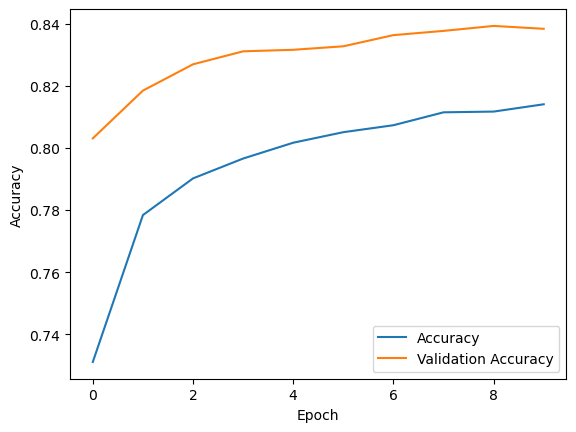

```python
plt.plot(hist_VGG.history["accuracy"])
plt.plot(hist_VGG.history['val_accuracy'])

plt.ylabel("Accuracy")
plt.xlabel("Epoch")
plt.legend(["Accuracy","Validation Accuracy"])

plt.show()
```

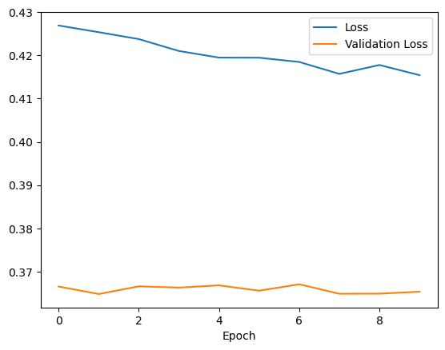

```python
plt.plot(hist_VGG.history['loss'])
plt.plot(hist_VGG.history['val_loss'])
plt.xlabel("Epoch")
plt.legend(["Loss","Validation Loss"])

plt.show()
```

### At the VGGNet, accuracy is relatively high even at the early epoch, but in total, 2nd model is better fitted than VGGNet model

### (4) 4th model -- ResNet

### Finally, ResNet is tried.

```python
base_model = tf.keras.applications.ResNet50(
    input_shape = (64,64,3),
    include_top=False,
    weights = 'imagenet'
    )
visualkeras.layered_view(base_model, legend = True)
```

[figure not shown]

```python
model_res = Sequential()
model_res.add(base_model)
model_res.add(Flatten())
model_res.add(BatchNormalization())
model_res.add(Dense(16, activation = 'relu'))
model_res.add(Dropout(0.5))
model_res.add(Dense(8, activation = 'relu'))
model_res.add(Dropout(0.5))
model_res.add(BatchNormalization())
model_res.add(Dense(1, activation = 'sigmoid'))
model_res.build(input_shape=(256, 64, 64, 3))
model_res.summary()
```

```
Model: "sequential_12"
_________________________________________________________________
 Layer (type)                Output Shape              Param #
=================================================================
 resnet50 (Functional)       (None, 2, 2, 2048)        23587712

 flatten_12 (Flatten)        (None, 8192)              0

 batch_normalization_21 (Bat  (None, 8192)             32768
 chNormalization)

 dense_28 (Dense)            (None, 16)                131088

 dropout_14 (Dropout)        (None, 16)                0

 dense_29 (Dense)            (None, 8)                 136

 dropout_15 (Dropout)        (None, 8)                 0

 batch_normalization_22 (Bat  (None, 8)                32
 chNormalization)

 dense_30 (Dense)            (None, 1)                 9

=================================================================
Total params: 23,751,745
Trainable params: 23,682,225
Non-trainable params: 69,520
_________________________________________________________________
```

### Compiling / Training

```python
base_model.trainable = False
model_res.compile(optimizer=opt_vgg, loss='binary_crossentropy', metrics=['accuracy'])
```

```python
hist_res = model_res.fit(data_train, validation_data=data_validate, epochs=10, verbose=1)
```

### Evaluation of ResNet model

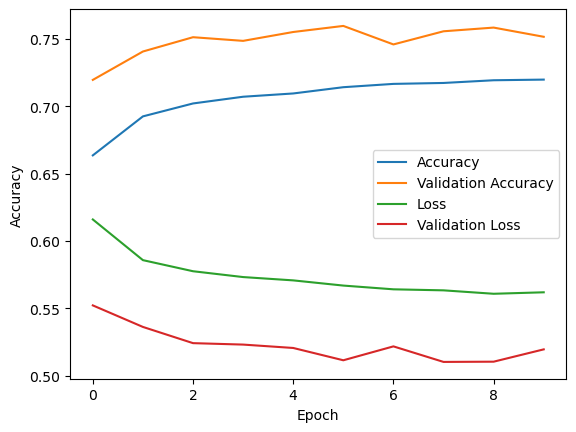

```python
plt.plot(hist_res.history["accuracy"])
plt.plot(hist_res.history['val_accuracy'])
plt.plot(hist_res.history['loss'])
plt.plot(hist_res.history['val_loss'])

plt.ylabel("Accuracy")
plt.xlabel("Epoch")
plt.legend(["Accuracy","Validation Accuracy","Loss","Validation Loss"])

plt.show()
```

### At the ResNet model, no overfitting is observed, but in total, accuracy is the lowest among 4 models

## 3. Discussion

### Normal CNN model, CNN model including Batch normalization, VGGNet model and ResNet model are tried for detecting cancer. Considering accuracy, CNN model with Batch normalization is the best. (accuracy: 0.9058, validation accuracy: 0.8789)

### Also this model decreases loss further. But there is some inconsistency between accuracy and validation accuracy, compared with 1st model (CNN without batch normalization). I do not have any idea about this background: in comparison with 2 model (1st & 2nd), the basic structure of layer is the same; 4 batch normalization layers are added to the 1st model. I guess that batch normalization layers might give rise to inconsistency.

### At VGGNet and ResNet, 2 things are found: 1) loss is relatively high, 2) validation accuracy is constantly higher than accuracy.

## 4. Conclusion

### At this mini project for detecting cancer, 4 models are tried. At the end, CNN model with batch normalization would be the best. (accuracy: 0.9058, validation accuracy: 0.8789) The effect of batch normalization would be confirmed.

### For test set, which is submitted to Kaggle site, score is 0.759.

## Submission

```python
image_test = pd.DataFrame({'id':os.listdir('/test/')})
generator_test = ImageDataGenerator(rescale=1./255)

data_test = generator_test.flow_from_dataframe(
    dataframe = image_test,
    x_col = 'id',
    directory = '/test/',
    class_mode=None,
    batch_size = 1,
    target_size = (64,64),
    shuffle=False
    )
```

```
Found 57458 validated image filenames.
```

```python
predictions = model_bn.predict(data_test, verbose=1)
```

```python
pred = np.transpose(predictions)[0]

print(pred)
```

```
[8.05367351e-01 9.19572294e-01 4.62446332e-01 ... 1.09523826e-04
 5.01714230e-01 1.20358784e-02]
```

```python
submission_df = pd.DataFrame()
submission_df['id'] = image_test['id'].apply(lambda x: x.split('.')[0])
submission_df['label'] = list(map(lambda x: 0 if x < 0.5 else 1, pred))

print(submission_df.head())

submission_df['label'].value_counts()
```

```
                                         id  label
0  00006537328c33e284c973d7b39d340809f7271b      1
1  0000ec92553fda4ce39889f9226ace43cae3364e      1
2  00024a6dee61f12f7856b0fc6be20bc7a48ba3d2      0
3  000253dfaa0be9d0d100283b22284ab2f6b643f6      0
4  000270442cc15af719583a8172c87cd2bd9c7746      0
```

```
0    41180
1    16278
Name: label, dtype: int64
```

```python
submission_df.to_csv('submission.csv', index=False)
```

## Reference

#### https://www.kaggle.com/competitions/histopathologic-cancer-detection/overview

#### https://www.kaggle.com/code/sandipanumbc/cancer-detection-with-vgg16-19-resnet50

#### https://keras.io/api/applications/vgg/